# ZEAL lipids — R/qtl (bcsft) LOD profiles + enzyme candidates, by lipid class

- Show All Code
- Hide All Code
- View Source

Multi-trait glycerolipid QTL overview: Haley–Knott interval mapping on the BC2S3 rtiger ancestry mosaic (B73=A / het=H / teosinte=B), marker set + genetic map = the TeoNAM JLM 0.1-cM grid (ZEAL mosaic projected on), taxon covariate, genome-wide 1000-permutation threshold. Phenotypes = per-genotype normalized HPLC-MS signal (peak-area of the ion current, mean over ~3 reps — NOT BLUEs, no spatial/mixed-model correction), preprocessed as below-detection (≤0)→NA, integer counts (×1e9), log10(count+1) for species and the provided class-sum columns; ratios are the file’s plant-level-averaged ratio columns (not recomputed), log10-transformed. Candidates = the B73 v5 glycerolipid gene set rebuilt from KEGG zma00561/zma00564 + CornCyc(E2P2) via MaizeMine (NOT lifted from AGPv4).

Author

Fausto Rodríguez-Zapata

Published

September 2, 2026

**What this is.** A single overview of the ZEAL glycerolipid QTL scan across all 133 lipid traits (115 species + 10 class sums + 8 ratios). Rather than one notebook per trait, it reports the traits that carry a **genome-wide significant** QTL, shows their LOD profiles grouped **by lipid class / ratio**, and annotates each significant peak with the glycerolipid **enzyme candidate(s)** whose B73 v5 locus falls inside the QTL support interval.

**ImportantPipeline, map, and genotype — read this first**

- **Scan:** `scripts/zeal_lipid_rqtl_scan.R` — joint `bcsft` (BC₂S₃) Haley–Knott `scanone` over all 133 traits at once, **taxon covariate** (5-family analog), one shared **1000-permutation** genome-wide null. Significance = per-trait 5% permutation LOD threshold.
- **No ZEAL genetic map is estimated**: every cM is a **TeoNAM JLM** distance (9,063-marker 0.1-cM grid); the ZEAL rtiger mosaic is *projected* onto it (nearest block). Markers `S<chr>_<pos_v5>`. Genotypes are HMM-error-corrected before the scan (`calc.genoprob(error.prob=0.01)`).
- **Phenotypes:** per-genotype **normalized MS signal** (peak-area of the ion current, HPLC-MS, mean over ~3 reps — *not* BLUEs, no spatial/mixed-model correction), IDs matched to the `nil_id` register (`scripts/zeal_lipid_pheno.R`); transform = **below-detection (≤0)→NA** (dropped, no 0-spike), integer counts (K=1e9), `log10(count+1)` for species and the **provided** class-sum columns; the ratios are the file’s **plant-level-averaged** ratio columns (lower variance than a ratio of means — a per-plant/spike-in normalization that sharpens the ratio peaks), `log10`-transformed. Sums/ratios are **not** recomputed from the species.
- **Candidates:** `scripts/zeal_lipid_candidates_v5.py` (KEGG→CornCyc/E2P2 via MaizeMine, v5 rebuild); symbols/function from the MaizeGDB curated annotation (`data/Zm00001eb.1.fulldata.txt`). Peak↔︎gene overlap by `scripts/zeal_lipid_qtl_annotate.R` / `scripts/zeal_lipid_qtl_enzyme_table.R`.

```r
library(here)
library(data.table)
library(qtl)
library(ggplot2)
library(ggrepel)

RQ <- here("results/sim/zeal/rqtl/lipid")
stopifnot(dir.exists(RQ)) # run: Rscript scripts/zeal_lipid_rqtl_scan.R (NPERM=1000 NCORES=1)

# joint LOD profile (marker, chr, pos[cM], <133 trait LOD columns>) + per-trait perm threshold
scan <- fread(file.path(RQ, "zeal_lipid_scanone_taxon.csv"))
perms <- readRDS(file.path(RQ, "zeal_lipid_perms_taxon.rds"))
thr5v <- setNames(as.numeric(summary(perms, alpha = 0.05)), colnames(perms))

summ <- fread(file.path(RQ, "zeal_lipid_qtl_summary.csv"))          # significant QTL
enz <- fread(file.path(RQ, "zeal_lipid_qtl_enzyme_candidates.csv")) # QTL × enzyme candidate

# trait -> lipid class + display group (species classes; class sums; ratios)
classify <- function(tr) fifelse(grepl("^[A-Za-z]+_[0-9]+_[0-9]+$", tr), "species",
  fifelse(grepl("^[A-Za-z]+$", tr), "sum", "ratio"))
lipid_class <- function(tr) fifelse(classify(tr) == "ratio", "ratio", sub("_.*$", "", tr))
sig_traits <- sort(unique(summ$trait))
```

## Significant QTL summary

```r
st <- summ[, .(
  trait, class, chr, `peak (Mb)` = round(peak_mb, 1), LOD = round(lod, 1),
  `5% thr` = round(get(if ("thresh" %in% names(summ)) "thresh" else "thr5"), 1),
  `CI (Mb)` = paste0(round(ci_left_mb, 1), "–", round(ci_right_mb, 1)),
  `CI width (Mb)` = round(width_mb, 2), marker
)][order(-LOD)]
knitr::kable(st, caption = sprintf(
  "Genome-wide significant lipid QTL (HK scanone, taxon covariate, 1000-perm 5%%): %d peaks across %d traits.",
  nrow(st), uniqueN(summ$trait)
))
```

Genome-wide significant lipid QTL (HK scanone, taxon covariate, 1000-perm 5%): 29 peaks across 22 traits.

| trait | class | chr | peak (Mb) | LOD | 5% thr | CI (Mb) | CI width (Mb) | marker |
| --- | --- | --- | --- | --- | --- | --- | --- | --- |
| MGDG_34_4 | species | 8 | 80.6 | 23.3 | 16.1 | 80–81.7 | 1.73 | S8_80647421 |
| DGDG_36_6 | species | 10 | 151.3 | 21.7 | 21.3 | 147.1–152.1 | 5.03 | S10_151305857 |
| DGDG_36_3 | species | 10 | 151.4 | 20.4 | 20.2 | 151.3–152.1 | 0.82 | S10_151402634 |
| PC_36_4 | species | 10 | 147.2 | 19.3 | 17.7 | 146.9–147.4 | 0.56 | S10_147183206 |
| PC_36_4 | species | 10 | 151.3 | 19.1 | 17.7 | 151.2–152.1 | 0.92 | S10_151305857 |
| SQDG_36_4 | species | 10 | 151.5 | 18.9 | 15.0 | 151.3–152.1 | 0.82 | S10_151528815 |
| SQDG_36_4 | species | 10 | 147.1 | 17.9 | 15.0 | 146.9–147.5 | 0.65 | S10_147103666 |
| PG_34_4 | species | 3 | 186.8 | 17.1 | 16.9 | 184.2–190 | 5.81 | S3_186796418 |
| PG_34_4 | species | 8 | 80.6 | 17.1 | 16.9 | 80–81.7 | 1.73 | S8_80647421 |
| DG_36_5 | species | 10 | 151.5 | 17.0 | 15.1 | 151.3–152.1 | 0.82 | S10_151528815 |
| DG_36_5 | species | 10 | 147.2 | 16.9 | 15.1 | 146.9–147.4 | 0.56 | S10_147213452 |
| PC_34_2 | species | 10 | 147.2 | 15.8 | 13.1 | 147.2–147.5 | 0.33 | S10_147249401 |
| SQDG_36_5 | species | 10 | 151.5 | 15.5 | 12.8 | 151.3–152.1 | 0.82 | S10_151528815 |
| PC_36_6 | species | 8 | 101.5 | 14.4 | 10.2 | 101.5–102.7 | 1.20 | S8_101509016 |
| DG_36_4 | species | 10 | 147.2 | 14.0 | 13.1 | 147.2–147.4 | 0.23 | S10_147249401 |
| SQDG_36_5 | species | 10 | 147.1 | 14.0 | 12.8 | 146.9–147.4 | 0.56 | S10_147103666 |
| PE_36_3 | species | 10 | 147.3 | 12.5 | 12.3 | 147.2–149.6 | 2.47 | S10_147262072 |
| PC_36_2 | species | 3 | 191.0 | 11.8 | 10.7 | 186.7–191.7 | 5.06 | S3_191019570 |
| PI_32_0 | species | 3 | 189.6 | 11.6 | 10.3 | 189.4–190 | 0.53 | S3_189565561 |
| PI_34_3 | species | 10 | 147.1 | 10.9 | 10.7 | 146.9–148.2 | 1.31 | S10_147103648 |
| PC_32_1 | species | 1 | 214.9 | 7.6 | 6.6 | 213.9–216.1 | 2.19 | S1_214916249 |
| PC_32_1 | species | 2 | 226.2 | 7.0 | 6.6 | 223.4–227.2 | 3.84 | S2_226203911 |
| LPE | sum | 3 | 7.9 | 6.5 | 6.5 | 5.2–9.4 | 4.22 | S3_7895212 |
| LPC_18_1 | species | 3 | 8.2 | 6.4 | 6.4 | 5.7–11.4 | 5.72 | S3_8242637 |
| PC_32_4 | species | 1 | 28.6 | 6.3 | 5.5 | 28.4–29.8 | 1.42 | S1_28589372 |
| PI | sum | 10 | 149.9 | 5.6 | 4.9 | 149.3–150.2 | 0.86 | S10_149866657 |
| MGDG_DGDG | ratio | 8 | 0.7 | 5.4 | 5.2 | 0.4–2.7 | 2.36 | S8_706451 |
| PI | sum | 10 | 147.2 | 5.3 | 4.9 | 145.7–148.2 | 2.50 | S10_147183206 |
| DG_34_6 | species | 2 | 29.1 | 5.0 | 4.5 | 25.5–30.5 | 5.00 | S2_29096655 |

## Enzyme candidates in the QTL intervals

Glycerolipid genes (B73 v5) whose locus falls inside a QTL’s LOD-support CI. Symbol + function are the MaizeGDB curated annotation; blank symbol = no curated symbol assigned in v5.

```r
et <- enz[, .(trait, chr, `peak (Mb)` = peak_mb, LOD = lod, `CI (Mb)` = ci_mb,
  `locus (v5)` = locus_id_v5, symbol, `enzyme / function` = enzyme_function)]
knitr::kable(et, caption = sprintf(
  "%d QTL×candidate rows; %d distinct enzymes (%d with a curated symbol).",
  nrow(et), uniqueN(enz$locus_id_v5), uniqueN(enz[symbol != ""]$locus_id_v5)
))
```

22 QTL×candidate rows; 15 distinct enzymes (6 with a curated symbol).

| trait | chr | peak (Mb) | LOD | CI (Mb) | locus (v5) | symbol | enzyme / function |
| --- | --- | --- | --- | --- | --- | --- | --- |
| DGDG_36_6 | 10 | 151.31 | 21.7 | 147.1-152.1 | Zm00001eb433110 |  | Tafazzin family protein (Fragment) |
| DGDG_36_6 | 10 | 151.31 | 21.7 | 147.1-152.1 | Zm00001eb433200 |  | 1-phosphatidylinositol 4-kinase |
| DGDG_36_6 | 10 | 151.31 | 21.7 | 147.1-152.1 | Zm00001eb434030 | o7 | Acyl-CoA Synthetase-Like Protein,4-coumarate-CoA ligase |
| PG_34_4 | 3 | 186.80 | 17.1 | 184.2-190.0 | Zm00001eb147990 | aldr11 |  |
| PG_34_4 | 3 | 186.80 | 17.1 | 184.2-190.0 | Zm00001eb148000 | aldr1 | aldose reductase,deoxymugineic acid synthase |
| PG_34_4 | 3 | 186.80 | 17.1 | 184.2-190.0 | Zm00001eb148010 |  |  |
| PG_34_4 | 3 | 186.80 | 17.1 | 184.2-190.0 | Zm00001eb148100 |  | Putative methyltransferase PMT11 |
| PG_34_4 | 3 | 186.80 | 17.1 | 184.2-190.0 | Zm00001eb148650 |  | Caffeoylshikimate esterase |
| PG_34_4 | 3 | 186.80 | 17.1 | 184.2-190.0 | Zm00001eb149130 |  | Methyltransferase |
| PE_36_3 | 10 | 147.26 | 12.5 | 147.2-149.6 | Zm00001eb433110 |  | Tafazzin family protein (Fragment) |
| PE_36_3 | 10 | 147.26 | 12.5 | 147.2-149.6 | Zm00001eb433200 |  | 1-phosphatidylinositol 4-kinase |
| PC_36_2 | 3 | 191.02 | 11.8 | 186.7-191.7 | Zm00001eb148650 |  | Caffeoylshikimate esterase |
| PC_36_2 | 3 | 191.02 | 11.8 | 186.7-191.7 | Zm00001eb149130 |  | Methyltransferase |
| PC_32_1 | 2 | 226.20 | 7.0 | 223.4-227.2 | Zm00001eb111920 |  | Putative methyltransferases-like |
| PC_32_1 | 2 | 226.20 | 7.0 | 223.4-227.2 | Zm00001eb111990 | plc3 | phospholipase C |
| PC_32_1 | 2 | 226.20 | 7.0 | 223.4-227.2 | Zm00001eb112440 |  |  |
| LPE | 3 | 7.90 | 6.5 | 5.2-9.4 | Zm00001eb121780 | hpc1 | patatin-like phospholipase A |
| LPC_18_1 | 3 | 8.24 | 6.4 | 5.7-11.4 | Zm00001eb121780 | hpc1 | patatin-like phospholipase A |
| LPC_18_1 | 3 | 8.24 | 6.4 | 5.7-11.4 | Zm00001eb122690 | mrpa7 | ABC transporter C family protein |
| PI | 10 | 149.87 | 5.6 | 149.3-150.2 | Zm00001eb433110 |  | Tafazzin family protein (Fragment) |
| PI | 10 | 149.87 | 5.6 | 149.3-150.2 | Zm00001eb433200 |  | 1-phosphatidylinositol 4-kinase |
| DG_34_6 | 2 | 29.10 | 5.0 | 25.5-30.5 | Zm00001eb076550 |  | 1-phosphatidylinositol-3-phosphate 5-kinase |

## LOD profiles by lipid class / ratio

Each figure is one lipid class (or the ratios); coloured lines are the class’s traits that carry a significant QTL, across the whole genome (all 10 chromosomes, TeoNAM cM). Dotted lines = each trait’s 5% permutation threshold; red points = significant peaks. **Dashed grey verticals** mark the glycerolipid candidate enzyme loci in the QTL intervals, labelled by `gene_label` (the MaizeGDB symbol, or the assembly locus id `Zm00001eb…` when no symbol is assigned).

```r
# long LOD for significant traits only
lodL <- melt(scan[, c("chr", "pos", sig_traits), with = FALSE],
  id.vars = c("chr", "pos"), variable.name = "trait", value.name = "LOD"
)
lodL[, trait := as.character(trait)][, grp := lipid_class(trait)]

# significant peaks (red points)
pk <- summ[, .(trait, chr, pos = peak_cm, LOD = lod)][, grp := lipid_class(trait)]

# candidate enzyme loci in the QTLs, placed on the TeoNAM cM axis; label = gene_label
nat <- fread(here("data/teonam/teonam_v5_native.tsv"))
bp2cm <- function(ch, bp) {
  n <- nat[chr_v5 == ch & is.finite(cm)][order(pos_v5)]
  if (nrow(n) < 2) NA_real_ else approx(n$pos_v5, n$cm, xout = bp, rule = 2)$y
}
cv5 <- fread(here("data/zeal/lipid_candidates_v5.tsv"))
cv5[, mid := (as.numeric(start) + as.numeric(end)) / 2]
ecand <- unique(enz[, .(locus = locus_id_v5, trait, chr, gene_label)])
ecand[, grp := lipid_class(trait)]
ecand <- merge(ecand, cv5[, .(locus = gene_v5, mid)], by = "locus", all.x = TRUE)
ecand[, cm := mapply(bp2cm, chr, mid)]
cand_grp <- unique(ecand[is.finite(cm), .(grp, chr, cm, gene_label)])

groups <- unique(lodL$grp)
groups <- groups[order(match(groups, c("DGDG", "MGDG", "DG", "PC", "PE", "PG", "PI", "SQDG", "LPC", "LPE", "ratio")))]
```

```r
for (g in groups) {
  d <- lodL[grp == g]
  trs <- sort(unique(d$trait))
  thrg <- data.table(trait = trs, thr = thr5v[trs])
  pkg <- pk[grp == g]
  cl <- cand_grp[grp == g]
  ytop <- max(d$LOD, na.rm = TRUE)
  cat(sprintf("\n\n### %s — %s\n\n", g, paste(trs, collapse = ", ")))
  p <- ggplot(d, aes(pos, LOD, colour = trait)) +
    geom_vline(data = cl, aes(xintercept = cm), inherit.aes = FALSE,
      linetype = "dashed", colour = "grey55", linewidth = 0.3) +
    geom_line(linewidth = 0.5) +
    geom_hline(data = thrg, aes(yintercept = thr, colour = trait),
      linetype = "dotted", linewidth = 0.3, show.legend = FALSE) +
    geom_point(data = pkg, aes(pos, LOD), colour = "red", size = 1.7, inherit.aes = FALSE) +
    ggrepel::geom_text_repel(
      data = cl, aes(x = cm, y = ytop * 1.12, label = gene_label), inherit.aes = FALSE,
      size = 3.5, colour = "grey15", angle = 90, hjust = 0, direction = "x",
      segment.size = 0.2, min.segment.length = 0, max.overlaps = Inf
    ) +
    expand_limits(y = ytop * 1.7) +
    facet_grid(~chr, scales = "free_x", space = "free_x", switch = "x") +
    labs(
      x = "Chromosome (cM, TeoNAM JLM map)", y = "LOD", colour = "trait",
      title = sprintf("ZEAL %s glycerolipid QTL — HK scanone, taxon covariate, 1000-perm 5%%", g),
      subtitle = "dashed grey = candidate enzyme loci (label = MaizeGDB symbol, else assembly locus id)"
    ) +
    theme_classic(base_size = 12) +
    theme(
      axis.text.x = element_blank(), axis.ticks.x = element_blank(),
      panel.spacing = unit(0.05, "lines"), strip.placement = "outside",
      strip.background = element_blank(), legend.position = "bottom"
    ) +
    scale_x_continuous(expand = c(0.01, 0))
  print(p)
  cat("\n")
}
```

### DGDG — DGDG_36_3, DGDG_36_6

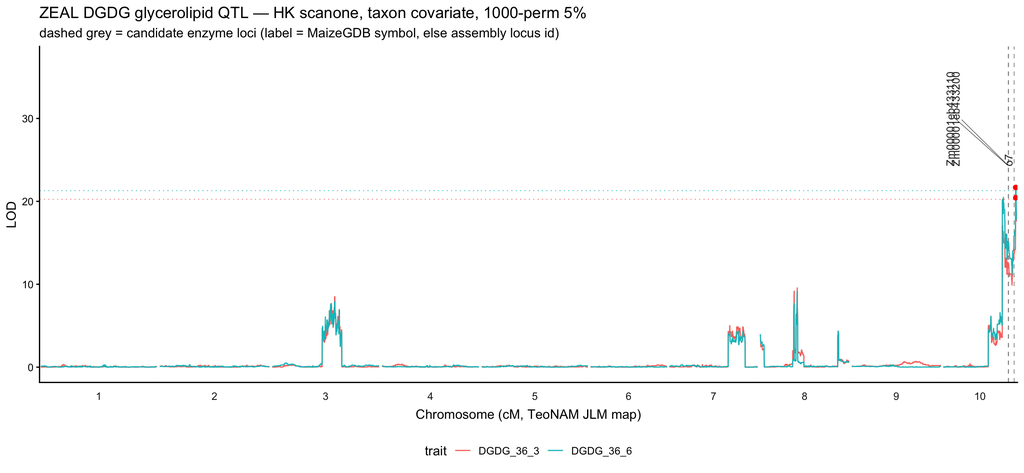

### MGDG — MGDG_34_4

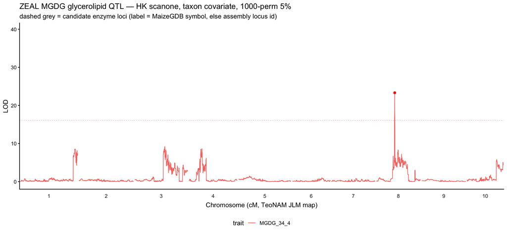

### DG — DG_34_6, DG_36_4, DG_36_5

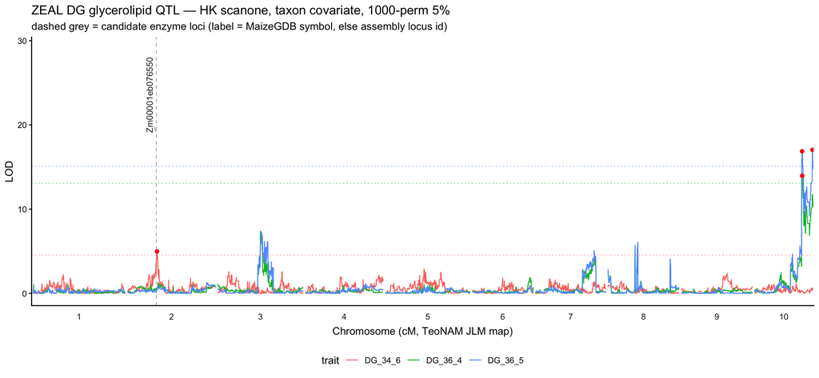

### PC — PC_32_1, PC_32_4, PC_34_2, PC_36_2, PC_36_4, PC_36_6

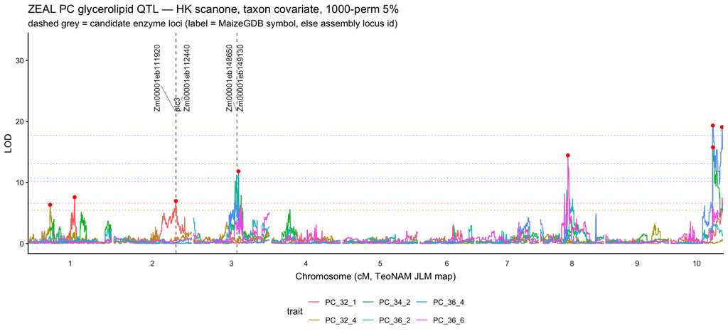

### PE — PE_36_3

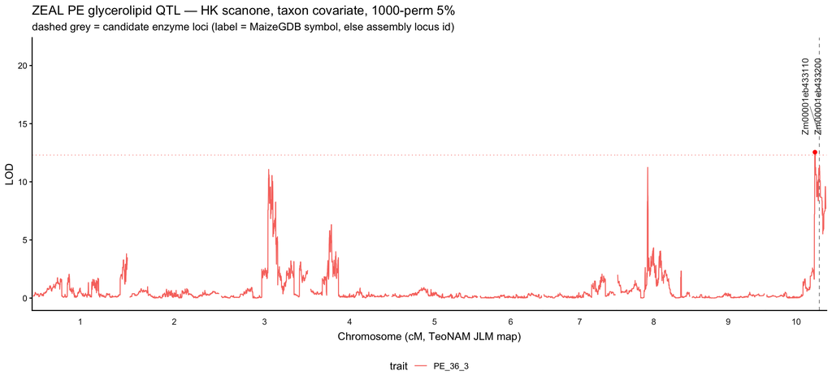

### PG — PG_34_4

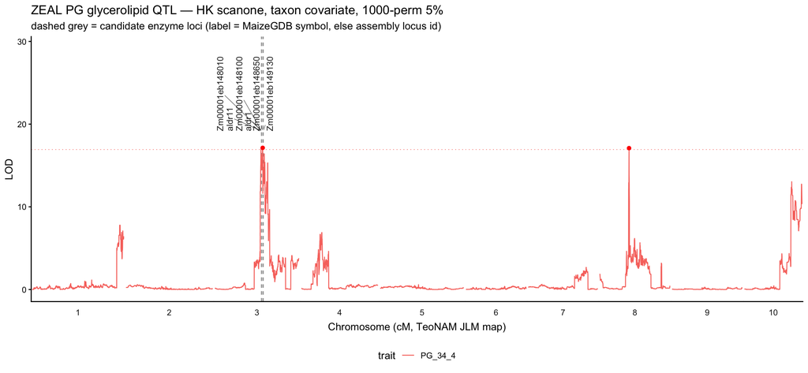

### PI — PI, PI_32_0, PI_34_3

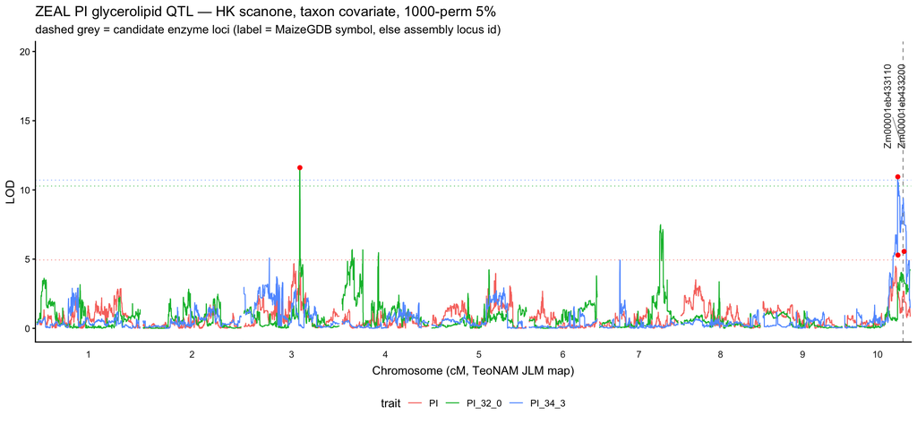

### SQDG — SQDG_36_4, SQDG_36_5

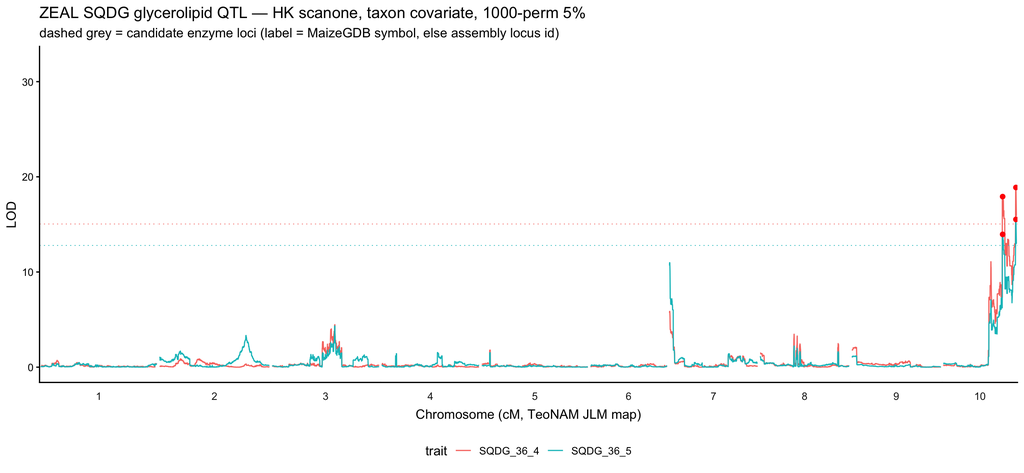

### LPC — LPC_18_1

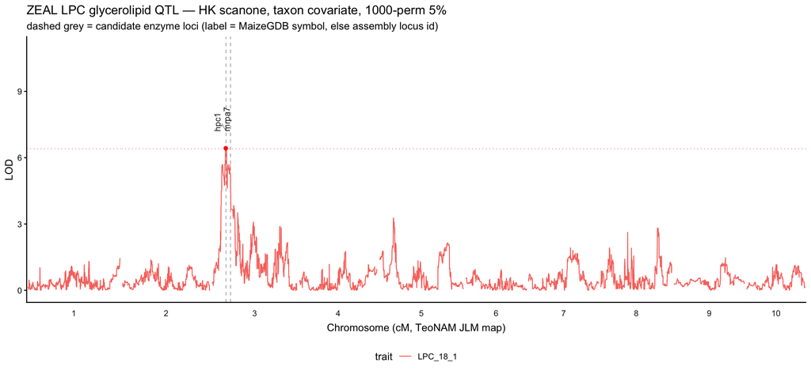

### LPE — LPE

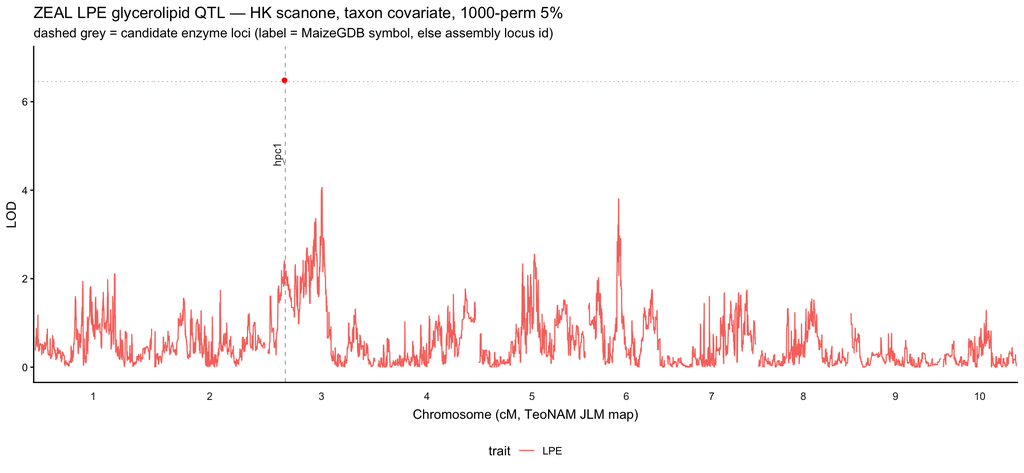

### ratio — MGDG_DGDG

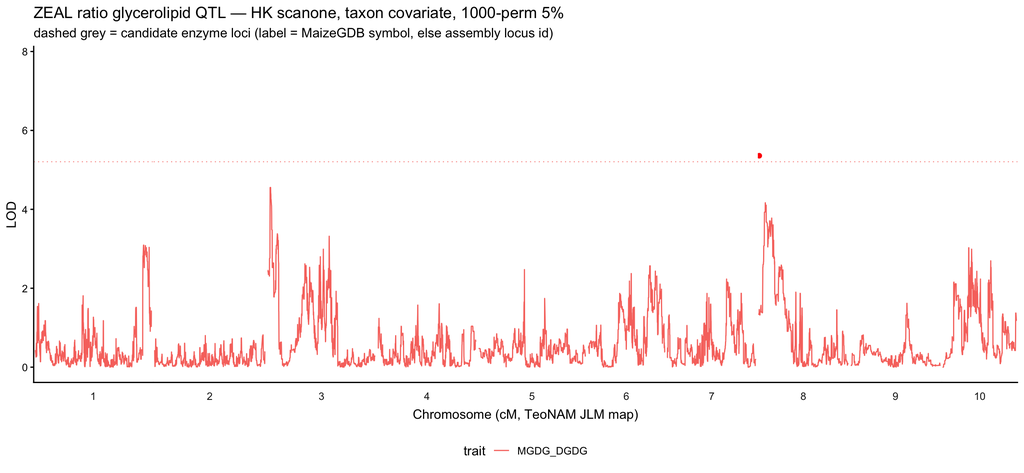

## Notes

- The strongest peak overall — **MGDG_34_4 on chr8 (~80.6 Mb, LOD 23.3)** — has **no glycerolipid candidate** in its CI: a novel locus or one acting through a gene outside the curated pathway set.
- **`hpc1`** (Zm00001eb121780, ZmPLA1.2, patatin-like phospholipase A — the High-PC1 gene) sits under the chr3 ~8 Mb **LPE** and **LPC_18_1** QTL: a phospholipase A1 producing lyso-phospholipids.
- The chr10 ~147–152 Mb region is a recurrent hotspot across DGDG/PC/SQDG/DG/PE/PI species and the PI sum; candidates there include a Tafazzin-family phospholipid acyltransferase (Zm00001eb433110), a 1-phosphatidylinositol 4-kinase (Zm00001eb433200), and `o7` (Zm00001eb434030).

## `hpc1` QTL — allele effect plots

`hpc1` (Zm00001eb121780, ZmPLA1.2, a patatin-like phospholipase A) is the glycerolipid candidate in the CI of the **LPE** and **LPC_18_1** QTL on chr3 (~8 Mb). The **first column is the whole ZEAL population** (all taxa pooled) allele effect; the remaining columns split it by donor taxon. Below is the phenotype (transformed normalized MS signal) by genotype class at each QTL’s peak marker — `A/A` = B73, `A/B` = heterozygote, `B/B` = teosinte introgression — coloured by donor taxon. A phospholipase A1 releases lyso-phospholipids, so a teosinte-allele effect on LPE/LPC is the mechanistically expected direction.

```r
# rebuild the joint cross (same csv the scan built) to pull genotypes at the peak markers
crossL <- read.cross(
  format = "csv", file = file.path(RQ, "zeal_lipid_cross.csv"),
  genotypes = c("A", "H", "B"), alleles = c("A", "B"),
  estimate.map = FALSE, BC.gen = 2, F.gen = 3
)
```

```
 --Read the following data:
     1395  individuals
     9063  markers
     134  phenotypes
 --Cross type: bcsft
```

```r
crossL <- jittermap(crossL)
crossL <- calc.genoprob(crossL, step = 1, error.prob = 0.01, map.function = "haldane") # for fitqtl (HK)
phe <- crossL$pheno
gmat <- pull.geno(crossL)
ssx <- fread(here("data/zeal/samplesheet_3way.csv"))[, .(pedigree, taxon)]

hpc1_qtl <- summ[trait %in% c("LPE", "LPC_18_1"), .(trait, chr, marker, peak_cm, lod)]
eff_one <- function(tr, mk) {
  data.table(
    trait = tr, marker = mk,
    taxon = ssx[match(as.character(phe$id), pedigree), taxon],
    geno = factor(c("A/A (B73)", "A/B", "B/B (teo)")[gmat[, mk]],
      levels = c("A/A (B73)", "A/B", "B/B (teo)")),
    y = as.numeric(phe[[tr]])
  )[is.finite(y) & !is.na(geno)]
}
ed <- rbindlist(Map(eff_one, hpc1_qtl$trait, hpc1_qtl$marker))
ed[, facet := sprintf("%s  (chr3 @ %s)", trait, marker)]
```

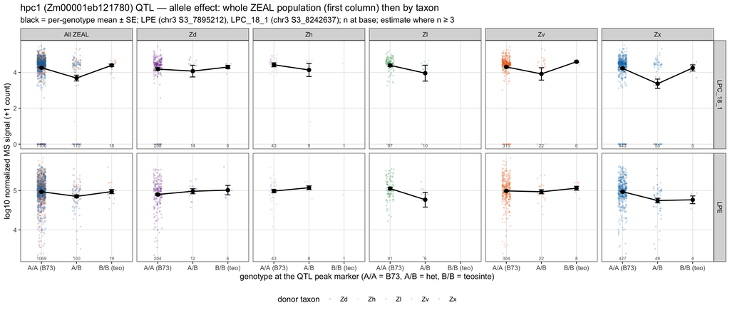

```r
# First column = the WHOLE ZEAL population (all taxa pooled) allele-effect; the rest =
# the per-taxon split. Black line/point = the panel's per-genotype mean ± SE across
# A/A→A/B→B/B; points coloured by donor taxon; n at the base; estimate drawn only where n≥3.
pal5 <- c(Zx = "#0571B0", Zv = "#E66101", Zl = "#008837", Zd = "#7B3294", Zh = "#C2A5CF")
d0 <- ed[taxon %in% names(pal5)]
taxa <- sort(unique(d0$taxon))
dd <- rbind(copy(d0)[, panel := "All ZEAL"], copy(d0)[, panel := taxon]) # pooled + per-taxon copies
dd[, panel := factor(panel, levels = c("All ZEAL", taxa))]
stat <- dd[, .(mean = mean(y), se = sd(y) / sqrt(.N), n = .N), by = .(trait, panel, geno)]
shown <- stat[n >= 3]
ggplot(dd, aes(geno, y)) +
  geom_jitter(aes(colour = taxon), width = 0.12, alpha = 0.15, size = 0.5) +
  geom_line(data = shown, aes(y = mean, group = interaction(trait, panel)), colour = "black", linewidth = 0.7) +
  geom_point(data = shown, aes(y = mean), colour = "black", size = 2.2) +
  geom_errorbar(data = shown, aes(y = mean, ymin = mean - se, ymax = mean + se), colour = "black", width = 0.15) +
  geom_text(data = stat, aes(label = n), y = -Inf, vjust = -0.6, size = 2.2, colour = "grey40") +
  facet_grid(trait ~ panel, scales = "free_y") +
  scale_colour_manual(values = pal5, name = "donor taxon") +
  labs(
    x = "genotype at the QTL peak marker (A/A = B73, A/B = het, B/B = teosinte)",
    y = "log10 normalized MS signal (+1 count)",
    title = "hpc1 (Zm00001eb121780) QTL — allele effect: whole ZEAL population (first column) then by taxon",
    subtitle = "black = per-genotype mean ± SE; LPE (chr3 S3_7895212), LPC_18_1 (chr3 S3_8242637); n at base; estimate where n ≥ 3"
  ) +
  theme_bw(base_size = 11) +
  theme(panel.grid.minor = element_blank(), legend.position = "bottom")
```

```r
# Effects from R/qtl fitqtl (Haley-Knott, the SAME model as the scan), at each QTL's peak
# marker. Reports the additive (…a) and dominance (…d) effect estimates ± SE with Wald
# p-values, plus the QTL's joint 2-df LOD and Pvalue(Chi2). All ZEAL = full cross + taxon
# dummy covariates (as in the scan); each taxon = subset cross. a>0 = teosinte(B) allele
# raises the log10 signal; d = het deviation. a/d shown only where all three genotype
# classes have n≥3 (otherwise not separable — reported NA).
tax_all <- ssx[match(as.character(crossL$pheno$id), pedigree), taxon]
lv <- levels(factor(tax_all))
cov_all <- as.data.frame(vapply(lv[-1], function(l) as.integer(tax_all == l), integer(length(tax_all))))
names(cov_all) <- lv[-1]
formA <- as.formula(paste("y ~ Q1 +", paste(names(cov_all), collapse = " + ")))
one_fit <- function(cross, tr, mk, covar = NULL, formula = y ~ Q1) {
  na_row <- data.table(add = NA_real_, add_SE = NA_real_, add_p = NA_real_, dom = NA_real_, dom_SE = NA_real_, dom_p = NA_real_, LOD = NA_real_, qtl_2df_p = NA_real_, n = "")
  pc <- which(names(cross$pheno) == tr)
  fin <- is.finite(cross$pheno[[pc]])
  g <- pull.geno(cross)[fin, mk]
  nAA <- sum(g == 1, na.rm = TRUE); nAB <- sum(g == 2, na.rm = TRUE); nBB <- sum(g == 3, na.rm = TRUE)
  ncell <- sprintf("%d/%d/%d", nAA, nAB, nBB)
  if (min(nAA, nAB, nBB) < 3) {
    na_row[, n := ncell]
    return(na_row)
  }
  pos <- find.markerpos(cross, mk)
  q <- makeqtl(cross, chr = pos$chr, pos = pos$pos, what = "prob")
  fit <- tryCatch(fitqtl(cross, pheno.col = pc, qtl = q, covar = covar, formula = formula, method = "hk", get.ests = TRUE, dropone = TRUE), error = function(e) NULL)
  if (is.null(fit)) {
    na_row[, n := ncell]
    return(na_row)
  }
  s <- summary(fit)
  E <- s$ests
  dfE <- s$result.full["Error", "df"]
  pit <- function(tt) if (is.na(tt)) NA_real_ else 2 * pt(-abs(tt), dfE)
  A <- E[grep("@.*a$", rownames(E))[1], ]
  D <- E[grep("@.*d$", rownames(E))[1], ]
  data.table(add = A["est"], add_SE = A["SE"], add_p = pit(A["t"]), dom = D["est"], dom_SE = D["SE"], dom_p = pit(D["t"]),
    LOD = s$result.full["Model", "LOD"], qtl_2df_p = s$result.full["Model", "Pvalue(Chi2)"], n = ncell)
}
efftab <- rbindlist(lapply(seq_len(nrow(hpc1_qtl)), function(i) {
  tr <- hpc1_qtl$trait[i]
  mk <- hpc1_qtl$marker[i]
  rows <- list(cbind(data.table(trait = tr, panel = "All ZEAL"), one_fit(crossL, tr, mk, covar = cov_all, formula = formA)))
  for (tx in lv) {
    idx <- which(tax_all == tx)
    if (length(idx) < 20) next
    rows[[length(rows) + 1]] <- cbind(data.table(trait = tr, panel = tx), one_fit(subset(crossL, ind = idx), tr, mk))
  }
  rbindlist(rows, fill = TRUE)
}), fill = TRUE)
fmtp <- function(p) ifelse(is.na(p), "—", ifelse(p < 1e-3, formatC(p, format = "e", digits = 1), sprintf("%.3f", p)))
nn <- c("add", "add_SE", "dom", "dom_SE", "LOD")
efftab[, (nn) := lapply(.SD, function(x) round(as.numeric(x), 3)), .SDcols = nn]
knitr::kable(efftab[order(trait, panel), .(
  trait, panel, `additive a` = add, `a SE` = add_SE, `a p` = fmtp(as.numeric(add_p)),
  `dominance d` = dom, `d SE` = dom_SE, `d p` = fmtp(as.numeric(dom_p)),
  LOD, `QTL 2df p` = fmtp(as.numeric(qtl_2df_p)), `n AA/AB/BB` = n
)], caption = "hpc1 QTL — additive (a) and dominance (d) effects from R/qtl **fitqtl** (Haley-Knott, same model as the scan) at the chr3 peak marker: whole ZEAL population (taxon-covariate model) then each taxon. a = teosinte(B)-allele additive effect on the log10 signal; d = heterozygote deviation; p = Wald t-test; QTL 2df p = joint genotype test (Pvalue(Chi2)). a/d shown only where all three classes have n≥3.")
```

hpc1 QTL — additive (a) and dominance (d) effects from R/qtl **fitqtl** (Haley-Knott, same model as the scan) at the chr3 peak marker: whole ZEAL population (taxon-covariate model) then each taxon. a = teosinte(B)-allele additive effect on the log10 signal; d = heterozygote deviation; p = Wald t-test; QTL 2df p = joint genotype test (Pvalue(Chi2)). a/d shown only where all three classes have n≥3.

| trait | panel | additive a | a SE | a p | dominance d | d SE | d p | LOD | QTL 2df p | n AA/AB/BB |
| --- | --- | --- | --- | --- | --- | --- | --- | --- | --- | --- |
| LPC_18_1 | All ZEAL | 0.068 | 0.127 | 0.589 | -0.647 | 0.163 | 7.6e-05 | 8.066 | 1.7e-06 | 1106/110/18 |
| LPC_18_1 | Zd | 0.057 | 0.225 | 0.800 | -0.168 | 0.368 | 0.649 | 0.046 | 0.900 | 208/14/6 |
| LPC_18_1 | Zh | NA | NA | — | NA | NA | — | NA | — | 43/9/1 |
| LPC_18_1 | Zl | NA | NA | — | NA | NA | — | NA | — | 97/10/0 |
| LPC_18_1 | Zv | 0.145 | 0.207 | 0.484 | -0.532 | 0.298 | 0.075 | 0.792 | 0.161 | 315/22/6 |
| LPC_18_1 | Zx | 0.012 | 0.260 | 0.963 | -0.867 | 0.303 | 0.004 | 5.692 | 2.0e-06 | 443/55/5 |
| LPE | All ZEAL | 0.004 | 0.041 | 0.917 | -0.126 | 0.054 | 0.019 | 5.102 | 6.5e-04 | 1069/100/19 |
| LPE | Zd | 0.055 | 0.080 | 0.489 | 0.027 | 0.137 | 0.843 | 0.211 | 0.615 | 204/12/6 |
| LPE | Zh | NA | NA | — | NA | NA | — | NA | — | 43/8/1 |
| LPE | Zl | NA | NA | — | NA | NA | — | NA | — | 91/9/0 |
| LPE | Zv | 0.034 | 0.062 | 0.578 | -0.056 | 0.096 | 0.556 | 0.090 | 0.813 | 304/22/8 |
| LPE | Zx | -0.103 | 0.088 | 0.239 | -0.120 | 0.101 | 0.233 | 4.106 | 7.8e-05 | 427/49/4 |